# Airbnb data for New York City 2019

Group Dol_R

8/20/2020

## Introduction

Airbnb is an online marketplace for accommodations and it has more than 150 million users worldwide. In this report, the listing activity and metrics in New York City for 2019 will be analyzed according to **New York City Airbnb Open Data** data from [*Kaggle*](https://www.kaggle.com/dgomonov/new-york-city-airbnb-open-data).

## Loading Libraries and Data

```r
library(readr)
library(tidyverse)
library(lubridate)
library(tinytex)
data <- read.csv("https://raw.githubusercontent.com/pjournal/boun01g-dol-r/gh-pages/NYC_assignment/AB_NYC_2019.csv", header = TRUE, check.names=TRUE)
```

## Overview and Manipulation of Data

### Variables

Numerical Variables: id, host_id, latitude, longitude, price, minimum_nights, number_of_reviews, last_review, reviews_per_month, calculated_host_listings_count, availability_365.All the numerical values can be considered as discrete.  
Categorical Variables: name, host_name, neighbourhood_group, neighbourhood, room_type  
Since host_id identifies the host, there is no need for host_name and the respective column can be removed.

```r
data$last_review <- ymd(data$last_review)
data %>% glimpse()
```

```
## Rows: 48,895
## Columns: 16
## $ id                             <int> 2539, 2595, 3647, 3831, 5022, 5099, 51…
## $ name                           <chr> "Clean & quiet apt home by the park", …
## $ host_id                        <int> 2787, 2845, 4632, 4869, 7192, 7322, 73…
## $ host_name                      <chr> "John", "Jennifer", "Elisabeth", "Lisa…
## $ neighbourhood_group            <chr> "Brooklyn", "Manhattan", "Manhattan", …
## $ neighbourhood                  <chr> "Kensington", "Midtown", "Harlem", "Cl…
## $ latitude                       <dbl> 40.64749, 40.75362, 40.80902, 40.68514…
## $ longitude                      <dbl> -73.97237, -73.98377, -73.94190, -73.9…
## $ room_type                      <chr> "Private room", "Entire home/apt", "Pr…
## $ price                          <int> 149, 225, 150, 89, 80, 200, 60, 79, 79…
## $ minimum_nights                 <int> 1, 1, 3, 1, 10, 3, 45, 2, 2, 1, 5, 2, …
## $ number_of_reviews              <int> 9, 45, 0, 270, 9, 74, 49, 430, 118, 16…
## $ last_review                    <date> 2018-10-19, 2019-05-21, NA, 2019-07-0…
## $ reviews_per_month              <dbl> 0.21, 0.38, NA, 4.64, 0.10, 0.59, 0.40…
## $ calculated_host_listings_count <int> 6, 2, 1, 1, 1, 1, 1, 1, 1, 4, 1, 1, 3,…
## $ availability_365               <int> 365, 355, 365, 194, 0, 129, 0, 220, 0,…
```

### NA values

```r
data %>% select(everything()) %>% summarise_all(funs(sum(is.na(.))))
```

```
##   id name host_id host_name neighbourhood_group neighbourhood latitude
## 1  0    0       0         0                   0             0        0
##   longitude room_type price minimum_nights number_of_reviews last_review
## 1         0         0     0              0                 0       10052
##   reviews_per_month calculated_host_listings_count availability_365
## 1             10052                              0                0
```

## Analysis

Average price per night is 152.72. There are 3 different types of rooms which are Private room, Entire home/apt, Shared room . Average prices per room type are :

```r
data %>% select(price, room_type) %>% group_by(room_type)%>% summarise(mean(price))
```

```
## # A tibble: 3 x 2
##   room_type       `mean(price)`
##   <chr>                   <dbl>
## 1 Entire home/apt         212.
## 2 Private room             89.8
## 3 Shared room              70.1
```

### Summary of Dataset

There are 48895 data points in total.

```r
data %>% summary()
```

```
##        id               name              host_id           host_name
##  Min.   :    2539   Length:48895       Min.   :     2438   Length:48895
##  1st Qu.: 9471945   Class :character   1st Qu.:  7822033   Class :character
##  Median :19677284   Mode  :character   Median : 30793816   Mode  :character
##  Mean   :19017143                      Mean   : 67620011
##  3rd Qu.:29152178                      3rd Qu.:107434423
##  Max.   :36487245                      Max.   :274321313
##
##  neighbourhood_group neighbourhood         latitude       longitude
##  Length:48895        Length:48895       Min.   :40.50   Min.   :-74.24
##  Class :character    Class :character   1st Qu.:40.69   1st Qu.:-73.98
##  Mode  :character    Mode  :character   Median :40.72   Median :-73.96
##                                         Mean   :40.73   Mean   :-73.95
##                                         3rd Qu.:40.76   3rd Qu.:-73.94
##                                         Max.   :40.91   Max.   :-73.71
##
##   room_type             price         minimum_nights    number_of_reviews
##  Length:48895       Min.   :    0.0   Min.   :   1.00   Min.   :  0.00
##  Class :character   1st Qu.:   69.0   1st Qu.:   1.00   1st Qu.:  1.00
##  Mode  :character   Median :  106.0   Median :   3.00   Median :  5.00
##                     Mean   :  152.7   Mean   :   7.03   Mean   : 23.27
##                     3rd Qu.:  175.0   3rd Qu.:   5.00   3rd Qu.: 24.00
##                     Max.   :10000.0   Max.   :1250.00   Max.   :629.00
##
##   last_review         reviews_per_month calculated_host_listings_count
##  Min.   :2011-03-28   Min.   : 0.010    Min.   :  1.000
##  1st Qu.:2018-07-08   1st Qu.: 0.190    1st Qu.:  1.000
##  Median :2019-05-19   Median : 0.720    Median :  1.000
##  Mean   :2018-10-04   Mean   : 1.373    Mean   :  7.144
##  3rd Qu.:2019-06-23   3rd Qu.: 2.020    3rd Qu.:  2.000
##  Max.   :2019-07-08   Max.   :58.500    Max.   :327.000
##  NA's   :10052        NA's   :10052
##  availability_365
##  Min.   :  0.0
##  1st Qu.:  0.0
##  Median : 45.0
##  Mean   :112.8
##  3rd Qu.:227.0
##  Max.   :365.0
##
```

### Pie Plots for Categorical Variables

Lets show the ratios of Room Types and Neigbours with pie charts.

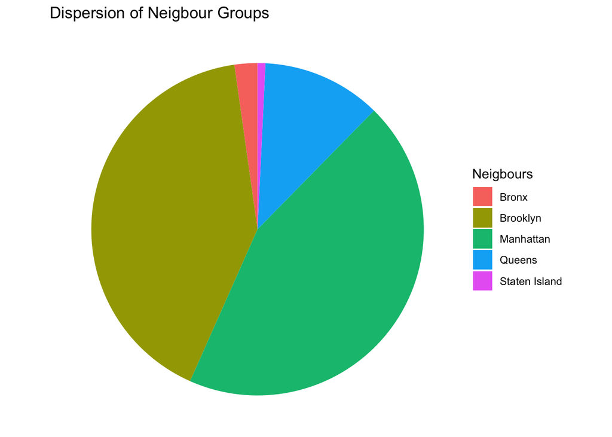

```r
df_neigbour <- data.frame(data$neighbourhood_group)
df_neigbour <- unlist(df_neigbour)
df_neigbour <- data.frame(df_neigbour)
pie_chart <- ggplot(df_neigbour) + geom_bar(mapping = aes(x = "", fill=df_neigbour ), width = 1) + coord_polar("y") +
  theme_void() # remove background, grid, numeric labels
pie_chart <- pie_chart + labs(x="", fill="Neigbours", title = "Dispersion of Neigbour Groups")
pie_chart
```

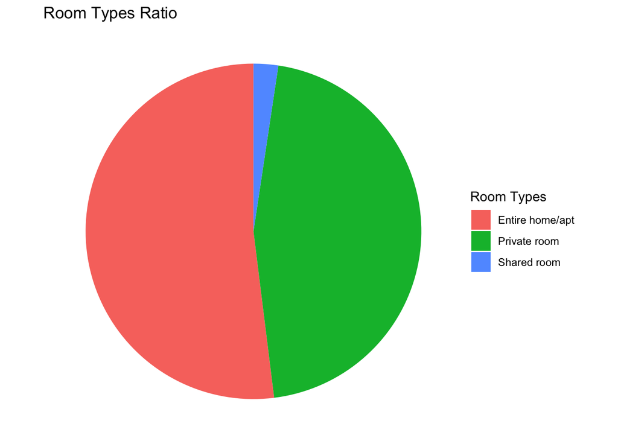

```r
df_rt <- data.frame(data$room_type)
df_rt <- unlist(df_rt)
df_rt <- data.frame(df_rt)
pie_chart2 <- ggplot(df_rt) + geom_bar(mapping = aes(x = "", fill=df_rt ), width = 1) + coord_polar("y") +
  theme_void() # remove background, grid, numeric labels
pie_chart2 <- pie_chart2 + labs(x="", fill="Room Types", title = "Room Types Ratio")
pie_chart2
```

### Plots for Numerical Variables

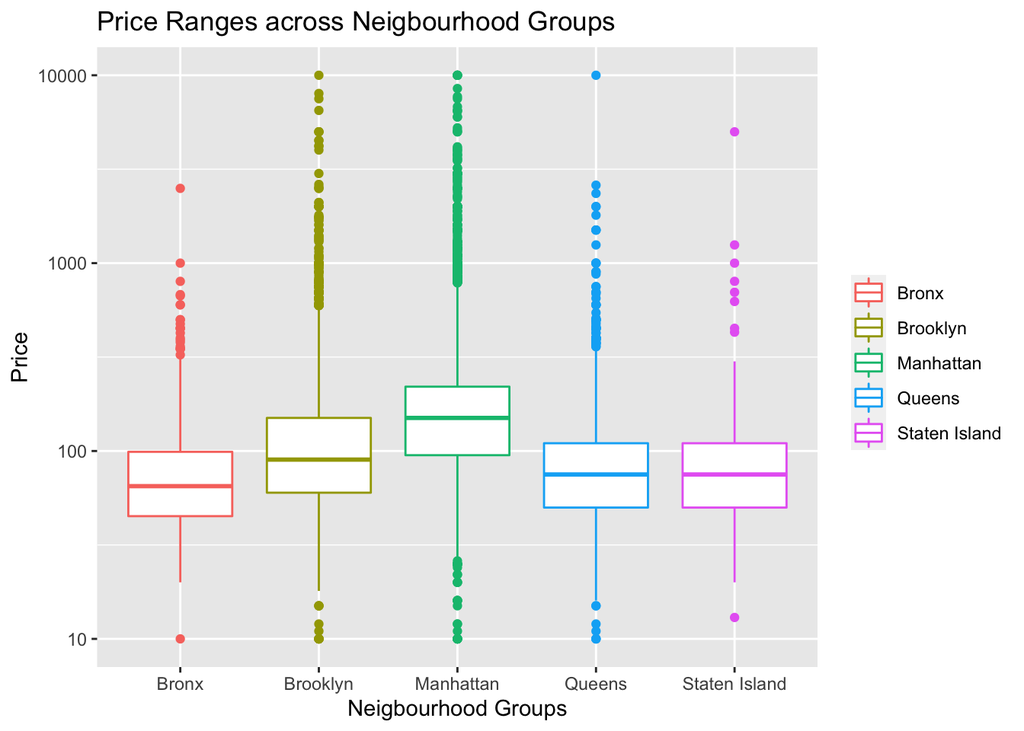

```r
box_df <- data %>% select(id, neighbourhood_group, price)

box_plot1 <- ggplot(box_df, aes(x=neighbourhood_group, y=price, color=neighbourhood_group)) + geom_boxplot() + scale_y_log10() +labs(x="Neigbourhood Groups", y="Price", title = "Price Ranges across Neigbourhood Groups") + theme(legend.title= element_blank())

box_plot1
```